# Quantitative Strategies on High Frequency Data

Academic year 2023/2024

## Approaches undertaken

Our project focused on Moving Averages (MAs), utilizing Crossing EMAs and Single EMA for both asset groups. We optimized MA parameters for each asset, incorporating them into the portfolio based on Net P&L in both Momentum and Mean-Reverting Strategies.

No additional assumptions have been considered, only the commonly accepted ones for both Group 1 and Group 2.

To determine optimal MAs parameters, we utilized both the HeatMap method and manual exploration. Our primary focus was identifying the most profitable configurations across the entire timeframe. In cases where multiple settings proved lucrative, we assessed their consistency in generating profits on a quarterly basis.

## Finally selected strategy for **group 1**

When assessing Group 1 assets encompassing two indexes, our analysis spanned Momentum and Mean-Reverting strategies. However, we encountered challenges in achieving positive P&Ls with the Mean-Reverting approach. Consequently, our focus shifted towards a Trending strategy, for which we identified optimal parameters leading to favorable outcomes.

In comparing strategies, the Crossing EMAs technique exhibited superior P&Ls compared to the Single EMA method. As a result, we opted for the Crossing EMAs approach and implemented the following set of parameters:

`NASDAQ - 35/134`

`SP500 - 55/80`

```
## [1] 115923.8
```

## Summary of results for **group 1**

| quarter | grossSR | netSR | grossCR | netCR | av.daily.ntrades | grossPnL | netPnL | stat |
| --- | --- | --- | --- | --- | --- | --- | --- | --- |
| 2021_Q1 | 2.44 | 1.78 | 10.84 | 7.36 | 14.48 | 34546.62 | 25426.62 | 23.80 |
| 2021_Q3 | 0.36 | -0.49 | 1.04 | -1.32 | 13.36 | 3686.71 | -5133.29 | -2.15 |
| 2021_Q4 | 4.79 | 4.14 | 26.33 | 22.41 | 13.52 | 70959.00 | 62039.00 | 92.49 |
| 2022_Q2 | 0.30 | -0.09 | 0.63 | -0.16 | 14.49 | 7325.08 | -2094.92 | -0.12 |
| 2022_Q4 | 0.55 | 0.11 | 1.68 | 0.32 | 13.63 | 11023.33 | 2163.33 | 0.24 |
| 2023_Q1 | 2.68 | 2.14 | 9.24 | 7.23 | 12.03 | 40843.04 | 33043.04 | 25.29 |
| 2023_Q2 | 0.62 | 0.04 | 1.82 | 0.10 | 11.75 | 7960.02 | 480.02 | 0.00 |

Even though we have positive Gross P&L for each quarter, due to the transaction costs, our Net P&L has become negative for two quarters. However, in comparison with the quarters which are positive, these losses do not have a huge impact on our model’s overall performance.

In reality, it is not always achievable to make profit consistently.

## PnL **Group 1** – 2021Q1

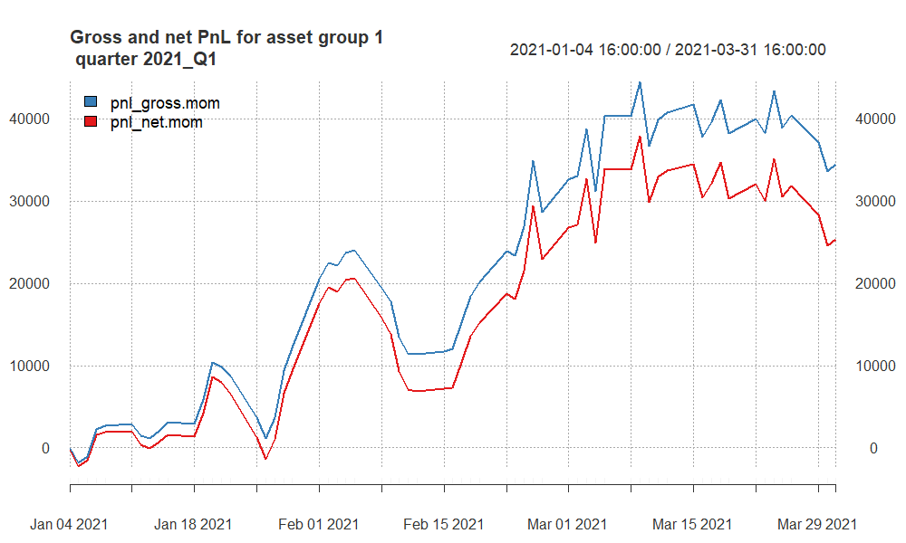

Began with modest returns, saw a significant profit surge in the second part of the quarter, but ended with a decrease in Net P&L from roughly $37,000 to $25,000 due to unprofitable final transactions.

## PnL **Group 1** – 2021Q3

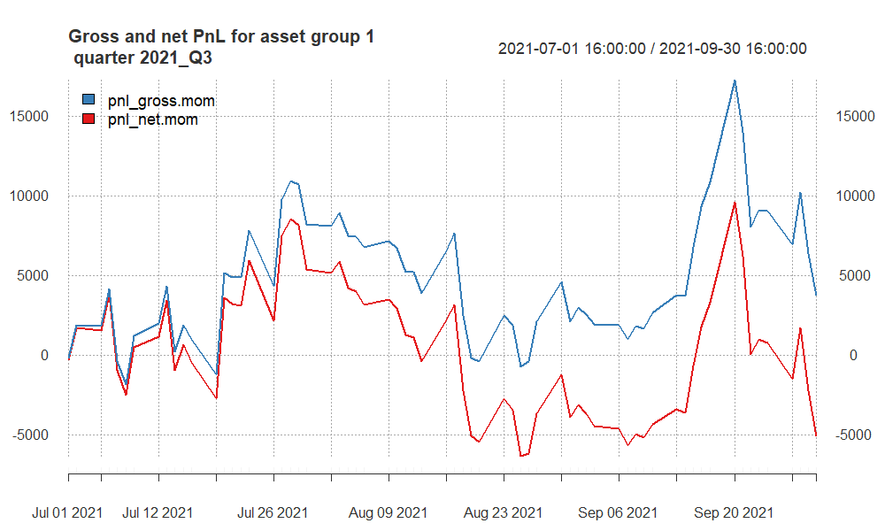

It has the lowest Net P&L value. Especially recent transactions have completely eradicated any earnings. In general, there is a considerable amount of erratic movement, particularly with a negative impact.

## PnL **Group 1** – 2021Q4

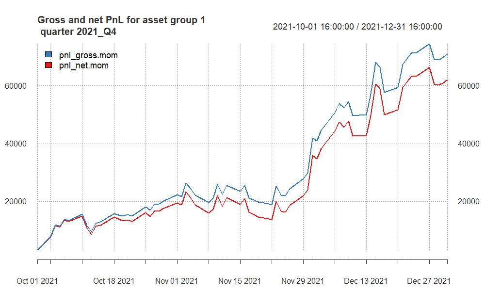

The quarter marked the highest profitability, yielding a net profit of around $62,000. The strategy has consistently stayed in positive territory, ensuring a continuous stream of profits throughout the entire quarter. The higher Sharpe ratio and Stat indicates strong risk-adjusted returns and the statistical significance, respectively.

## PnL **Group 1** – 2022Q2

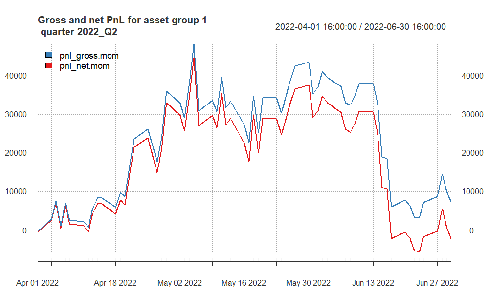

During this quarter, the number of average daily trades is the highest. The strategy proved itself in the mid-quarter, but ended up with negative return due to losses from positions as well as transaction costs.

## PnL **Group 1** – 2022Q4

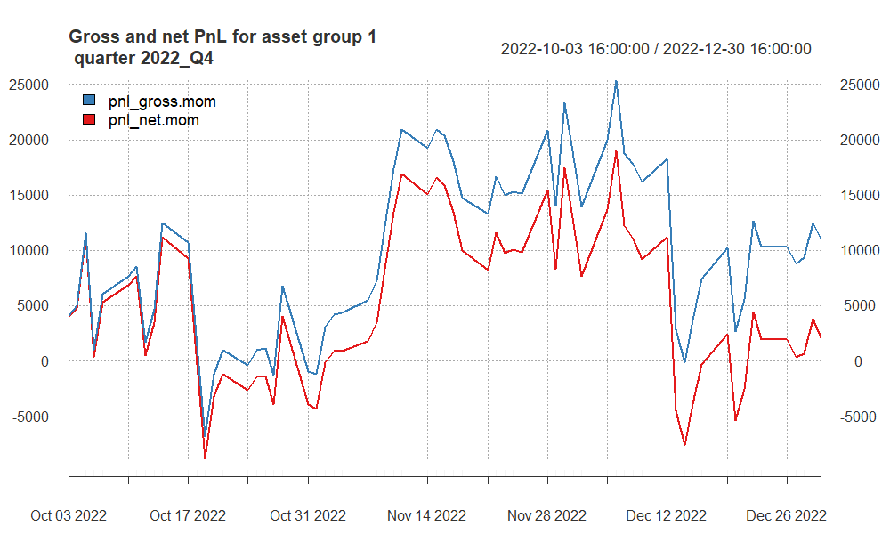

This quarter shows positive success rates, gains before and after costs. The difference between Gross and Net is about $9,000 - our gains from positions has not been that much, mostly small gains from a lot of positions. This is the reason why we have $9,000 transaction costs.

## PnL **Group 1** – 2023Q1

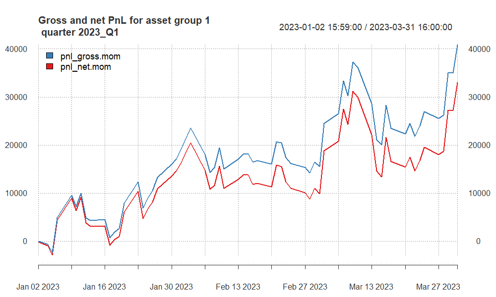

The approach consistently maintained a profitable P&L, and recent transactions have propelled it to its peak P&L level. For such a significant profit, transaction costs are only $ 8,000. Unlike 2022Q4, we have entered **fewer trades**, but **profitable** ones.

## PnL **Group 1** – 2023Q2

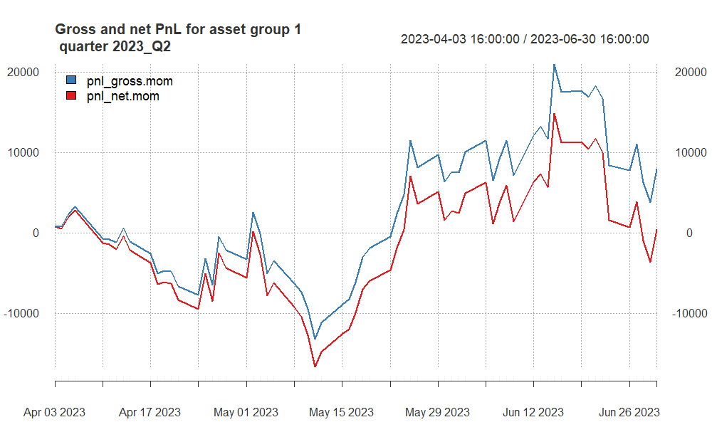

Following a challenging first half of the quarter marked by substantial losses, the strategy managed to recover in the latter part, yielding a profit of $15,000. Unfortunately, the positive trend was short-lived, as the strategy experienced a subsequent decline, nearly reaching zero.

## Finally selected strategy for **group 2**

For Group 2 assets which includes two currencies and two commodities, we checked Momentum and Mean-Reverting strategies. Based on our research we decided to continue with to Mean-Reverting strategy because of its profitability.

We started with finding the optimal parameters for each of them individually, and then combining as a portfolio the ones that reached desirable outcomes.

After our research, we decided to remove AUD and CAD. They didn’t yield much profit and the results was not reliable for such reason.

The P&Ls of Crossing EMAs was higher that Single EMA technique, so we preferred Crossing EMAs approach and used below parameters:

`XAG - 67/118`

`XAU - 191/570`

```
## [1] 81657
```

## Summary of results for **group 2**

| quarter | grossSR | netSR | grossCR | netCR | av.daily.ntrades | grossPnL | netPnL | stat |
| --- | --- | --- | --- | --- | --- | --- | --- | --- |
| 2021_Q1 | -0.88 | -1.18 | -1.43 | -1.75 | 7.45 | -14618.0 | -19526.0 | -5.20 |
| 2021_Q3 | -0.05 | -0.55 | -0.09 | -0.88 | 7.84 | -543.5 | -5926.5 | -1.57 |
| 2021_Q4 | 3.82 | 3.35 | 13.25 | 11.39 | 7.91 | 39326.6 | 34165.6 | 40.21 |
| 2022_Q2 | 1.60 | 1.10 | 3.46 | 2.30 | 7.47 | 16908.7 | 11622.7 | 5.64 |
| 2022_Q4 | 0.29 | -0.02 | 0.77 | -0.04 | 7.10 | 4561.2 | -237.8 | 0.00 |
| 2023_Q1 | -0.12 | -0.48 | -0.19 | -0.73 | 7.36 | -1586.7 | -6438.7 | -1.36 |
| 2023_Q2 | 5.69 | 5.32 | 17.52 | 15.81 | 7.92 | 73239.7 | 67997.7 | 66.70 |

The strategy experienced mixed performance in the initial quarters, marked by negative returns and varying risk-adjusted metrics. However, it showed a significant improvement in later quarters, especially in Q4 2021 and Q2 2023, with strong positive performance, high Sharpe and Calmar Ratios, and substantial profits.

## PnL **Group 2** – 2021Q1

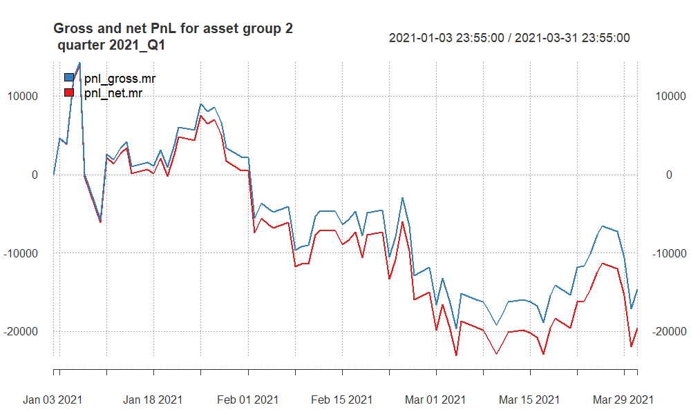

- Substantial negative returns with both gross and net Sharpe Ratios in the negative.
- Negative Calmar Ratios indicate poor risk-adjusted performance.
- Significant losses in both gross and net profits.

## PnL **Group 2** – 2021Q3

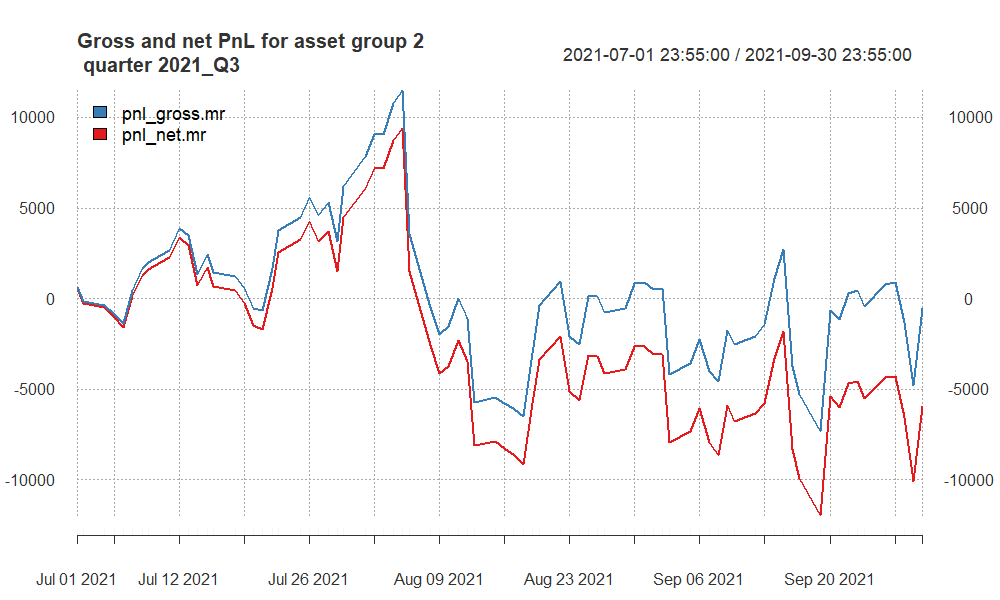

- Almost $6000 net loss comes from mainly unsuccessful trades and TCs.
- Negative CR ratios indicates poor risk-adjusted performance

## PnL **Group 2** – 2021Q4

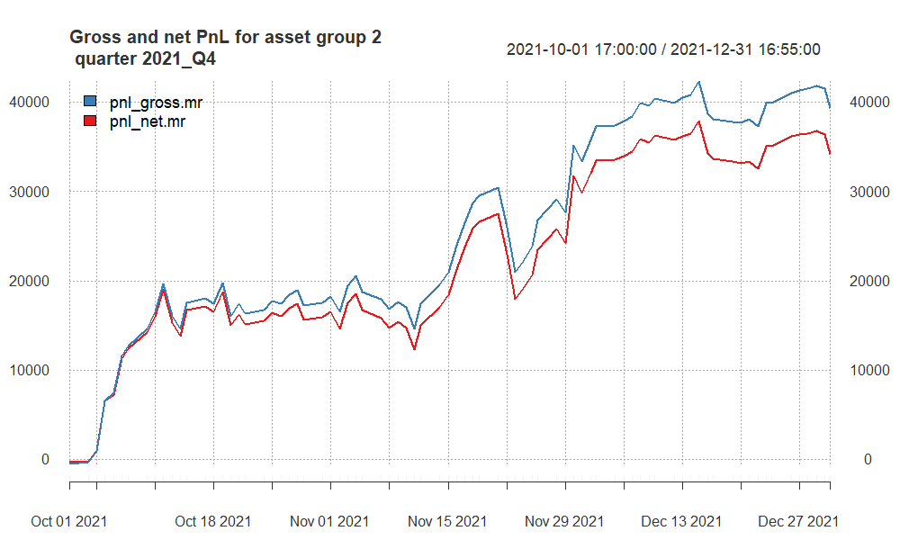

- Strong positive performance with high Sharpe Ratios, indicating good risk-adjusted returns.
- High gross and net Calmar Ratios suggest favorable risk-adjusted performance.
- Significant positive gross and net profits, with a positive statistical measure.

## PnL **Group 2** – 2022Q2

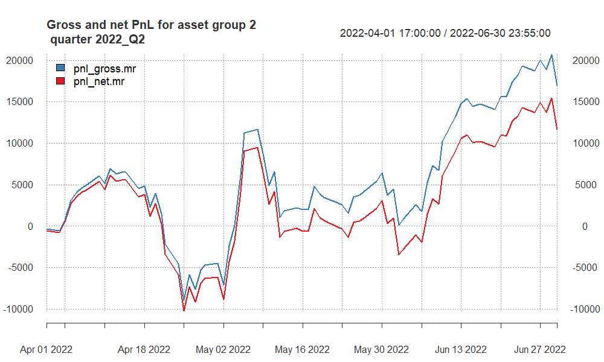

- Positive gross and net Sharpe Ratios, indicating positive risk-adjusted returns.
- Positive gross and net Calmar Ratios suggest good risk-adjusted performance.
- Positive gross and net profits, with a positive statistical measure.

## P&L **Group 2** – 2022Q4

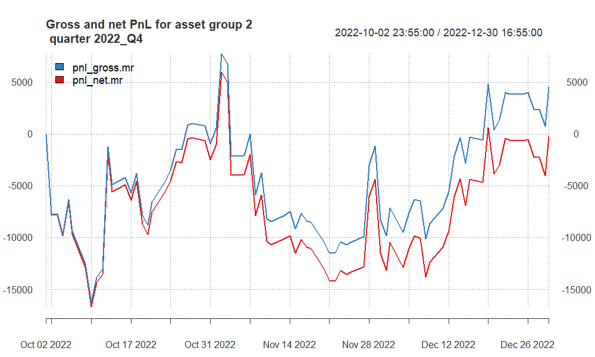

- Even though it has $4,500 Gross profit, after subtracting the costs, we have $-238 net loss.
- We cannot see a particular trend, it has been zigzaging.

## P&L **Group 2** – 2023Q1

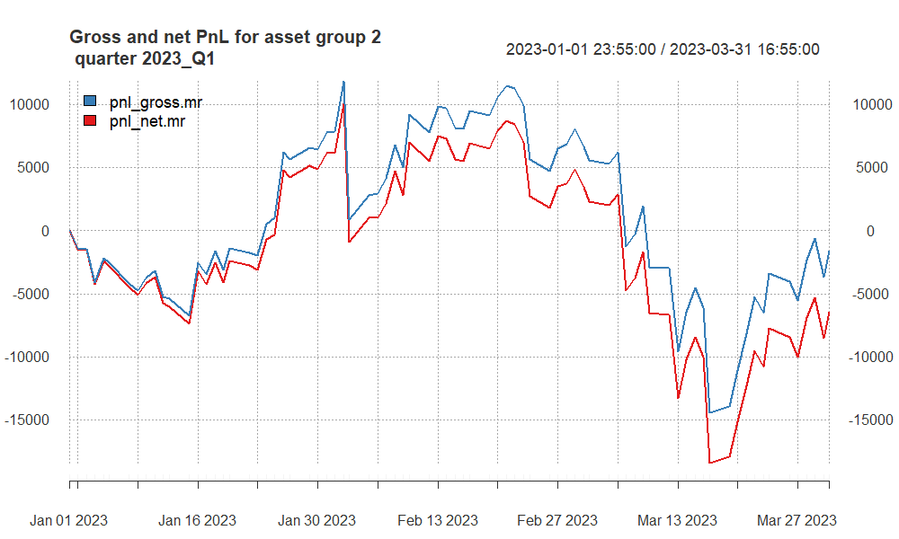

- We cannot see the continuation of positive trend in terms of P&L from previous quarter.
- After reaching almost $9,000 profit due to fluctuations it ended up in loss.

## P&L **Group 2** – 2023Q2

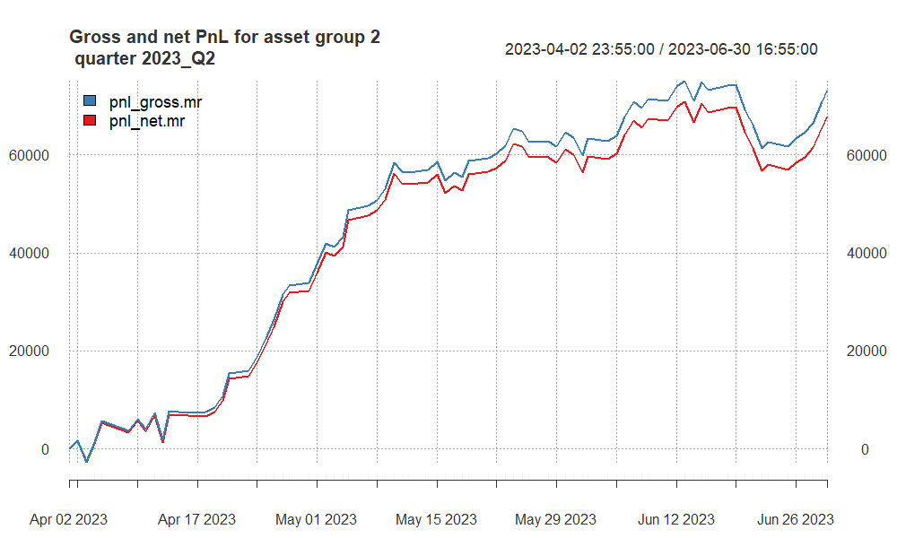

- Very strong positive performance with Sharpe Ratios, indicating excellent risk-adjusted returns.
- High gross and net Calmar Ratios also suggest outstanding risk-adjusted performance.
- Significant positive gross and net profits, with a positive statistical measure.

## Summary and conclusions

Implementing the portfolio approach in our analysis, we found that within the first group, the NASDAQ played a significant role, contributing 77% to the total profit and loss. Shifting focus to the second group, a concentrated strategy on commodities, particularly Silver, resulted in a noteworthy total profit of $81,600. Noteworthy adjustments were made for Gold, including the application of higher memory exponential moving averages (EMAs) due to its elevated transaction costs.

In summary, our strategy exhibited consistent results during the in-sample period, albeit with performance fluctuations across quarters.